# Final Exam

```r
FuelData <- FuelData[, Missing_Percent < 33]
FuelData <- na.omit(FuelData)

## Convert categorical variables to factors
FuelData$state <- as.factor(FuelData$state)
FuelData$fuel_type_code_pudl <- as.factor(FuelData$fuel_type_code_pudl)
FuelData$plant_name_eia <- as.factor(FuelData$plant_name_eia)
FuelData$utility_name_eia <- as.factor(FuelData$utility_name_eia)

##Conver Categorical to numeric
FuelData$fuel_cost_per_mmbtu <- as.numeric(FuelData$fuel_cost_per_mmbtu)
FuelData$total_fuel_cost <- as.numeric(FuelData$total_fuel_cost)

##Convert numeric to categorical
FuelData$plant_id_eia <- as.character(FuelData$plant_id_eia)
FuelData$plant_id_pudl <- as.character(FuelData$plant_id_pudl)
FuelData$utility_id_eia <- as.character(FuelData$utility_id_eia)
FuelData$utility_id_pudl <- as.character(FuelData$utility_id_pudl)
summary(FuelData)
```

```
 report_date        plant_id_eia       plant_id_pudl                            plant_name_eia
 Length:267910      Length:267910      Length:267910      Walter Scott Jr Energy Center:   581
 Class :character   Class :character   Class :character   Victor J Daniel Jr           :   569
 Mode  :character   Mode  :character   Mode  :character   Williams                     :   548
                                                          Clay Boswell                 :   547
                                                          Georgia-Pacific Cedar Springs:   534
                                                          Marion                       :   527
                                                          (Other)                      :264604
 utility_id_eia     utility_id_pudl                         utility_name_eia      state
 Length:267910      Length:267910      Tennessee Valley Authority   :  5153   TX     : 27973
 Class :character   Class :character   Virginia Electric & Power Co :  4967   FL     : 13647
 Mode  :character   Mode  :character   PacifiCorp                   :  3367   CA     : 13571
                                       Duke Energy Carolinas, LLC   :  3253   PA     : 13154
                                       Georgia Power Co             :  3087   IL     : 10977
                                       Public Service Co of Colorado:  2911   NY     :  9713
                                       (Other)                      :245172   (Other):178875
 fuel_type_code_pudl fuel_received_units fuel_mmbtu_per_unit fuel_cost_per_mmbtu fuel_received_mmbtu
 coal: 60228         Min.   :       1    Min.   :   0.078    Min.   :   -71.93   Min.   :8.000e-01
 gas :166598         1st Qu.:   11149    1st Qu.:   1.024    1st Qu.:     2.62   1st Qu.:2.298e+04
 oil : 41084         Median :  120622    Median :   1.043    Median :     3.97   Median :3.984e+05
                     Mean   :  691810    Mean   :   6.118    Mean   :    15.87   Mean   :1.453e+06
                     3rd Qu.:  721398    3rd Qu.:   5.880    3rd Qu.:     6.97   3rd Qu.:2.008e+06
                     Max.   :48206176    Max.   :1049.000    Max.   :562572.19   Max.   :2.488e+07

 total_fuel_cost     fuel_cost_per_mmbtu_source sulfur_content_pct ash_content_pct  data_maturity
 Min.   : -3123662   Length:267910              Min.   :0.0000     Min.   : 0.000   Length:267910
 1st Qu.:   174406   Class :character           1st Qu.:0.0000     1st Qu.: 0.000   Class :character
 Median :  1418210   Mode  :character           Median :0.0000     Median : 0.000   Mode  :character
 Mean   :  4635326                              Mean   :0.2928     Mean   : 2.075
 3rd Qu.:  6273863                              3rd Qu.:0.2000     3rd Qu.: 0.000
 Max.   :656044928                              Max.   :6.8000     Max.   :73.979
```

```r
str(FuelData)
```

```
'data.frame':   267910 obs. of  18 variables:
 $ report_date               : chr  "2008-01-01T00:00:00.000Z" "2008-02-01T00:00:00.000Z" "2008-03-01T00:00:00.000Z" "2008-04-01T00:00:00.000Z" ...
 $ plant_id_eia              : chr  "3" "3" "3" "3" ...
 $ plant_id_pudl             : chr  "32" "32" "32" "32" ...
 $ plant_name_eia            : Factor w/ 1717 levels "2 AC Station",..: 104 104 104 104 104 104 104 104 104 104 ...
 $ utility_id_eia            : chr  "195" "195" "195" "195" ...
 $ utility_id_pudl           : chr  "18" "18" "18" "18" ...
 $ utility_name_eia          : Factor w/ 1045 levels "Acadia Power Partners",..: 28 28 28 28 28 28 28 28 28 28 ...
 $ state                     : Factor w/ 50 levels "AK","AL","AR",..: 2 2 2 2 2 2 2 2 2 2 ...
 $ fuel_type_code_pudl       : Factor w/ 3 levels "coal","gas","oil": 1 1 1 1 1 1 1 1 1 1 ...
 $ fuel_received_units       : int  311653 246983 292376 353083 337140 299531 282146 283287 414388 372175 ...
 $ fuel_mmbtu_per_unit       : num  23 23 23 22.9 22.9 ...
 $ fuel_cost_per_mmbtu       : num  2.13 2.14 2.57 2.79 2.79 ...
 $ fuel_received_mmbtu       : num  7183512 5679396 6720962 8092480 7715892 ...
 $ total_fuel_cost           : num  15312976 12173918 17302334 22556884 21512616 ...
 $ fuel_cost_per_mmbtu_source: chr  "mixed" "mixed" "mixed" "mixed" ...
 $ sulfur_content_pct        : num  0.488 0.502 0.506 0.5 0.528 ...
 $ ash_content_pct           : num  5.45 5.59 5.51 5.59 5.31 ...
 $ data_maturity             : chr  "final" "final" "final" "final" ...
 - attr(*, "na.action")= 'omit' Named int [1:28694] 9614 9615 9616 9617 9618 9619 9620 9621 9625 9626 ...
  ..- attr(*, "names")= chr [1:28694] "9614" "9615" "9616" "9617" ...
```

```r
## Count negative fuel costs
sum(FuelData$total_fuel_cost < 0, na.rm = TRUE)
```

```
[1] 43
```

```r
## View the negative records
Negative_Costs <- FuelData %>%
  filter(total_fuel_cost < 0)

## Summary of negative values
summary(Negative_Costs$total_fuel_cost)
```

```
    Min.  1st Qu.   Median     Mean  3rd Qu.     Max.
-3123662 -1326836  -313048  -772605  -103043    -2365
```

```r
## Randomly sample approximately 2% of the observations
Sample_Index <- sample(1:nrow(FuelData), 0.02 * nrow(FuelData))
FuelSample <- FuelData[Sample_Index,]


## Create a dataset containing only the numeric variables for clustering
Cluster_Data <- FuelSample %>%
  select(fuel_received_units,
         fuel_mmbtu_per_unit,
         fuel_cost_per_mmbtu,
         fuel_received_mmbtu,
         total_fuel_cost,
         sulfur_content_pct,
         ash_content_pct)

## Standardize the variables so each contributes equally
Cluster_Data <- scale(Cluster_Data)
Cluster_Data <- as.data.frame(Cluster_Data)
summary(Cluster_Data)
```

```
 fuel_received_units fuel_mmbtu_per_unit fuel_cost_per_mmbtu fuel_received_mmbtu total_fuel_cost
 Min.   :-0.541218   Min.   :-0.74661    Min.   :-0.20658    Min.   :-0.6197     Min.   :-0.6044
 1st Qu.:-0.533237   1st Qu.:-0.63210    1st Qu.:-0.11829    1st Qu.:-0.6105     1st Qu.:-0.5822
 Median :-0.447844   Median :-0.62978    Median :-0.08700    Median :-0.4562     Median :-0.4224
 Mean   : 0.000000   Mean   : 0.00000    Mean   : 0.00000    Mean   : 0.0000     Mean   : 0.0000
 3rd Qu.: 0.003686   3rd Qu.:-0.03901    3rd Qu.:-0.01852    3rd Qu.: 0.2622     3rd Qu.: 0.2191
 Max.   : 9.799798   Max.   : 2.73347    Max.   :39.49235    Max.   : 8.8334     Max.   :16.7015
 sulfur_content_pct ash_content_pct
 Min.   :-0.4019    Min.   :-0.4006
 1st Qu.:-0.4019    1st Qu.:-0.4006
 Median :-0.4019    Median :-0.4006
 Mean   : 0.0000    Mean   : 0.0000
 3rd Qu.:-0.1284    3rd Qu.:-0.4006
 Max.   : 7.7894    Max.   :11.7537
```

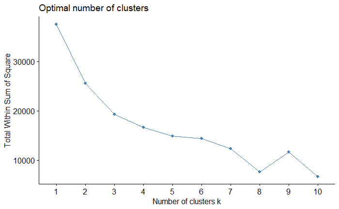

```r
## Run an elbow chart to determine the best fit of K without over-fitting the algorithm
fviz_nbclust(Cluster_Data, kmeans, method = "wss")
```

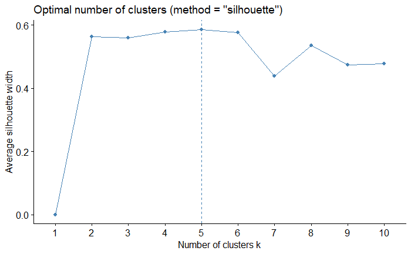

```r
## Confirm the choice of K using silhouette values to maximize cluster separation
fviz_nbclust(Cluster_Data, kmeans, method = "silhouette")
```

```r
##K Value will be 5 for the remainder of this project

## Based on both methods, K =  appears to provide a reasonable balance between cluster separation and model complexity
Num_KClust <- kmeans(Cluster_Data, centers = 5, nstart = 25)
## Display the number of transactions assigned to each cluster
Num_KClust$size
```

```
[1] 3377  752    4  273  952
```

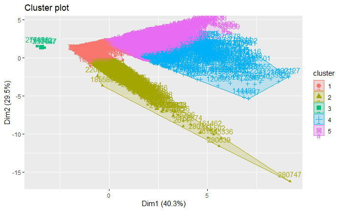

```r
## Visualize the clusters using a plot
fviz_cluster(Num_KClust, data = Cluster_Data)
```

```r
## Append cluster assignments to both the scaled numerical data and the original dataset
Cluster_Data <- cbind(Cluster_Data, "Cluster" = Num_KClust$cluster)
FuelSample <- cbind(FuelSample , "Cluster" = Num_KClust$cluster)

## Calculate average values for each variable within each cluster to aid interpretation
Cluster_Means <- aggregate(FuelSample[, c(10:14, 16:17)], by = list(Cluster = FuelSample$Cluster), mean)
Cluster_Means
```

| Cluster | fuel_received_units | fuel_mmbtu_per_unit | fuel_cost_per_mmbtu | fuel_received_mmbtu | total_fuel_cost | sulfur_content_pct | ash_content_pct |
| --- | --- | --- | --- | --- | --- | --- | --- |
| 1 | 295009.29 | 2.165752 | 8.681774 | 309092.426 | 1352732.4 | 0.03247256 | 0.000000 |
| 2 | 3319236.11 | 1.027542 | 4.425882 | 3400167.550 | 14458331.9 | 0.00000000 | 0.000000 |
| 3 | 177.75 | 1.004750 | 1566.011322 | 178.554 | 288688.6 | 0.00000000 | 0.000000 |
| 4 | 432668.94 | 21.002320 | 2.337193 | 8770355.716 | 20234505.6 | 1.50776776 | 8.929485 |
| 5 | 104123.39 | 20.369977 | 2.417996 | 1982933.171 | 4432248.1 | 1.10667784 | 9.292875 |

```r
Std_Dev_Means <- aggregate(Cluster_Data, by = list(Cluster = Cluster_Data$Cluster), mean)

## Export cluster means for further examination. File added to GitHub along with assignment
write.csv(Cluster_Means, "Cluster_Means.csv", row.names = FALSE)
write.csv(Std_Dev_Means, "Std_Dev_Means.csv", row.names = FALSE)


## Compare cluster averages against overall dataset averages to identify distinguishing characteristics
summary(FuelSample)
```

```
 report_date        plant_id_eia       plant_id_pudl                               plant_name_eia
 Length:5358        Length:5358        Length:5358        Bowen                           :  21
 Class :character   Class :character   Class :character   E W Brown                       :  15
 Mode  :character   Mode  :character   Mode  :character   F B Culley                      :  14
                                                          Scrubgrass Generating Company LP:  14
                                                          South Oak Creek                 :  14
                                                          Wateree                         :  14
                                                          (Other)                         :5266
 utility_id_eia     utility_id_pudl                         utility_name_eia     state
 Length:5358        Length:5358        Tennessee Valley Authority   : 105    TX     : 553
 Class :character   Class :character   Virginia Electric & Power Co :  94    CA     : 269
 Mode  :character   Mode  :character   Georgia Power Co             :  79    FL     : 256
                                       Public Service Co of Colorado:  70    IL     : 246
                                       Duke Energy Carolinas, LLC   :  66    PA     : 243
                                       Wisconsin Electric Power Co  :  65    GA     : 204
                                       (Other)                      :4879    (Other):3587
 fuel_type_code_pudl fuel_received_units fuel_mmbtu_per_unit fuel_cost_per_mmbtu fuel_received_mmbtu
 coal:1225           Min.   :       1    Min.   : 0.08644    Min.   :  -1.245    Min.   :       2
 gas :3333           1st Qu.:   10210    1st Qu.: 1.02400    1st Qu.:   2.626    1st Qu.:   21793
 oil : 800           Median :  119448    Median : 1.04300    Median :   3.997    Median :  388107
                     Mean   :  692340    Mean   : 6.19939    Mean   :   7.811    Mean   : 1471219
                     3rd Qu.:  697055    3rd Qu.: 5.88000    3rd Qu.:   6.999    3rd Qu.: 2093680
                     Max.   :13228464    Max.   :28.58000    Max.   :1739.020    Max.   :22441826

 total_fuel_cost     fuel_cost_per_mmbtu_source sulfur_content_pct ash_content_pct  data_maturity
 Min.   :    -2365   Length:5358                Min.   :0.0000     Min.   : 0.000   Length:5358
 1st Qu.:   170454   Class :character           1st Qu.:0.0000     1st Qu.: 0.000   Class :character
 Median :  1413816   Mode  :character           Median :0.0000     Median : 0.000   Mode  :character
 Mean   :  4700545                              Mean   :0.2939     Mean   : 2.106
 3rd Qu.:  6405471                              3rd Qu.:0.2000     3rd Qu.: 0.000
 Max.   :134657440                              Max.   :5.9900     Max.   :63.900

    Cluster
 Min.   :1.000
 1st Qu.:1.000
 Median :1.000
 Mean   :2.005
 3rd Qu.:2.000
 Max.   :5.000
```

```r
## compare Fuel type category to identifies any similarities in the clusters
table(FuelSample$Cluster, FuelSample$fuel_type_code_pudl)
```

```
    coal  gas  oil
  1    0 2577  800
  2    0  752    0
  3    0    4    0
  4  273    0    0
  5  952    0    0
```

```r
## Even without the fuel type being included in the clustering there is a strong separation when tabling showing a clear pattern between the clustering variables and the fuel type
```

Cluster 1 – Low-Volume Natural Gas and Oil Plants -Below-average fuel received and energy production -Below-average total fuel cost -Low sulfur and ash content -Contains the majority of natural gas plants and all oil plants -Interpretation: Smaller or lower-utilization clean-burning facilities, including many peaking plants.

Cluster 2 – Large-Scale Natural Gas Plants -Highest fuel received units (+2.05) -Above-average total fuel received and fuel cost -Very low sulfur and ash content -Entirely natural gas -Interpretation: Large, high-output natural gas generating stations operating at a much larger scale than Cluster 1.

Cluster 3 – Fuel Cost Outlier -Extremely high fuel cost per MMBtu (+35.55) -All other variables below average -Only 4 observations -Interpretation: This cluster represents unusual fuel purchase records or pricing anomalies rather than a meaningful operational category. Because it contains only four observations, it should be interpreted as an outlier cluster rather than a typical group of power plants.

Overall statement: In appears that the predominantly coal clusters have the hightest amount of MMBtu per unit meaning they output the most energy per unit of coal however at the same point it seems that these clusters also contribute to the most pollution by looking at the sulfur content and ash content.